# Ravenswood Peer School Working File

Qingyang Zhang & Dorna Abdi

2023-03-09

# Import data

For more data field references: https://caaspp-elpac.ets.org/caaspp/ResearchFileFormatSB?ps=true&lstTestYear=2022&lstTestType=B

# Wrangling

TODO:

generate an equivalent dataset for Test.ID==2, i.e. math results  
decide on grade list > type of schools  
there are still 57 missing values in score when merging with demo

Decisions:

- keep charter schools for now
- drop “declined to state” and keep only one variable for parental education
- use “Currently EL/or not” as the one variable for ELLs

```r
select_cols <- c('School.Code',
                  'Student.Group.ID',
                  'Students.Tested')

# All Students  001
# Disability Status Reported disabilities   128
# Economic Status   Economically disadvantaged  031
# English-Language Fluency EL (English learner) 160
# Race and Ethnicity
## American Indian or Alaska Native 075, Asian  076, Black or African American  074
## Filipino 077, Hispanic or Latino 078, Native Hawaiian or Pacific Islander    079
## White    080, Two or more races  144
# Gender    Female  004
# Parent Education
## Not a high school graduate   090
select_groups <- c(1, 128, 31, 160, 75, 76, 74, 77, 78, 79, 80, 144, 4, 90)

caaspp22_ela_pivoted <- caaspp22 %>%
  # Grade 13 means all grades, Test.ID = 1 (ELA)
  filter(Grade==13 & Test.ID==1) %>%
  # public schools (7), Direct(9)/Locally(10) Funded Charter School
  filter(Type.ID==7 | Type.ID==9 | Type.ID==10) %>%
  select(all_of(select_cols)) %>%
  filter(Student.Group.ID %in% select_groups) %>%
  # merging on student group name
  left_join(y=student_groups, by = c("Student.Group.ID" = "Demographic ID")) %>%
  rename("Demographic.ID.Num" = "Demographic ID Num",
         "Demographic.Name" = "Demographic Name") %>%
  select(all_of(c('School.Code',
                  'Students.Tested',
                  'Demographic.Name'))) %>%
  # pivot from long from to wide
  # each student group for a school is pivoted from a row to a val in column
  pivot_wider(names_from = Demographic.Name, values_from = 'Students.Tested')
```

## Select Sample

### Grade Spans

```r
caaspp22_grade <- caaspp22 |>
  group_by(School.Code) |> # 10,258 Unique School Codes
  filter(School.Code != 0 & Grade != 13) |>
  mutate(Grade.Count = n_distinct(Grade)) |>
  mutate(Grade.List = paste0(unique(Grade), collapse = ','))

grade_count <- caaspp22 |>
  group_by(School.Code) |> # 10,258 Unique School Codes
  filter(School.Code != 0 & Grade != 13) |>
  summarise(Grade.Count = n_distinct(Grade))

grade_list <- caaspp22 |>
  group_by(School.Code) |> # 10,258 Unique School Codes
  filter(School.Code != 0 & Grade != 13) |>
  summarise(Grade.List = paste0(unique(Grade), collapse = ','))

grades <- grade_count |>
  left_join(y=grade_list, by=c("School.Code" = "School.Code"))

school_type_table <- as.data.frame(
  table(grades$Grade.List, grades$Grade.Count)) |>
  setNames(c('grade_list', 'grade_count', 'freq')) |>
  filter(freq != 0)

# write.csv(school_type_table,file='data/school_type.csv')

typical_span <- c(
  '3,4,5', '3,4,5,6', '3,4,5,6,7,8', '3,4,5,6,7,8,11', '6,7,8', '6,7,8,11', '7,8', '7,8,11')

grade_atypical_span <- grades |>
  filter(!Grade.List %in% typical_span)

is_grade_atypical_span <- grade_atypical_span$School.Code
```

In our attempt to tackle the inconsistency in the combinations of grade levels, we eliminate the non-traditional schools because they are probably not representative of schools as a whole and are likely going through some type of transition (opening/closing/expanding). We consulted Batson from Ravenswood District, and decided to include schools with the following grade spans:

- 3,4,5
- 3,4,5,6
- 3,4,5,6,7,8
- 3,4,5,6,7,8,11
- 6,7,8
- 6,7,8,11
- 7,8
- 7,8,11

This includes 74% of the data (7629/10258 schools) and would give more confidence that schools are more directly comparable.

### Outcome inspection

```r
grade_non_missing <- caaspp22 |>
  # select 10258 schools (1 more since there is one school only have math scores)
  filter(School.Code > 0) |>
  # select only ELA results
  filter(Test.ID==1) |>
  # select `All Students`
  filter(Student.Group.ID == 1) |>
  filter(Grade != 13) |>
  # select rows where `Score` is '' or '*'
  filter(Mean.Scale.Score != '' & Mean.Scale.Score != '*') |>
  group_by(School.Code) |>
  summarise(Non.Missing.Grade.Count = n_distinct(Grade),
            Non.Missing.Grade.List = paste0(unique(Grade), collapse = ','))

# find schools where there are all missing grades
grade_all_missing <- grade_non_missing |>
  right_join(y=grades, by = c("School.Code" = "School.Code")) |>
  filter(is.na(Non.Missing.Grade.Count))

# find schools where there is only one non-missing grade and it is grade 11
grade_all_missing_but_11 <- grade_non_missing |>
  right_join(y=grades, by = c("School.Code" = "School.Code")) |>
  filter(Non.Missing.Grade.Count == 1 & Grade.Count > 1 & Non.Missing.Grade.List == '11')

is_grade_all_missing <- grade_all_missing$School.Code
is_grade_all_missing_but_11 <- grade_all_missing_but_11$School.Code
```

### Missing values

Noticeably there are a lot of missing values. For some of the student subgroups, the number of missing values are as high as more than 50%. In average, there are more than 2 missing values for every row. The specific distribution could be seen below.

Besides `NA` value, there are also a lot of `*` in the table. These two types of missing values are generated by two different mechanism:

- `NA`: comes from the pivoting process, i.e. there is not even a row for that specific student group for that specific school
- `*`: comes from the original dataset (the original dataset has no `NA` value) It is for privacy reasons, and theoretically indicates small values.

```r
# NA for original data
caaspp22 %>% summarise_all(~ sum(is.na(.))) # NA in each column
```

```
##   County.Code District.Code School.Code  Filler Test.Year Student.Group.ID
## 1           0             0           0 3855781         0                0
##   Test.Type Total.Tested.at.Reporting.Level
## 1         0                               0
##   Total.Tested.with.Scores.at.Reporting.Level Grade Test.ID Students.Enrolled
## 1                                           0     0       0                 0
##   Students.Tested Mean.Scale.Score Percentage.Standard.Exceeded
## 1               0                0                            0
##   Percentage.Standard.Met Percentage.Standard.Met.and.Above
## 1                       0                                 0
##   Percentage.Standard.Nearly.Met Percentage.Standard.Not.Met
## 1                              0                           0
##   Students.with.Scores Area.1.Percentage.Above.Standard
## 1                    0                                0
##   Area.1.Percentage.Near.Standard Area.1.Percentage.Below.Standard
## 1                               0                                0
##   Area.2.Percentage.Above.Standard Area.2.Percentage.Near.Standard
## 1                                0                               0
##   Area.2.Percentage.Below.Standard Area.3.Percentage.Above.Standard
## 1                                0                                0
##   Area.3.Percentage.Near.Standard Area.3.Percentage.Below.Standard
## 1                               0                                0
##   Area.4.Percentage.Above.Standard Area.4.Percentage.Near.Standard
## 1                                0                               0
##   Area.4.Percentage.Below.Standard Type.ID
## 1                                0       0
```

```r
table(rowSums(is.na(caaspp22))) # NA in each row
```

```
##
##       1
## 3855781
```

```r
# NA for pivoted
caaspp22_ela_pivoted %>% summarise_all(~ sum(is.na(.))) # NA in each column
```

```
## # A tibble: 1 × 15
##   School.Code All S…¹ Female Econo…² Black…³ Ameri…⁴ Asian Hispa…⁵ White Not a…⁶
##         <int>   <int>  <int>   <int>   <int>   <int> <int>   <int> <int>   <int>
## 1           0       0    271     152    1985    5515  2405     214   611     992
## # … with 5 more variables: `Reported disabilities` <int>,
## #   `Two or more races` <int>, `EL (English learner)` <int>, Filipino <int>,
## #   `Native Hawaiian or Pacific Islander` <int>, and abbreviated variable names
## #   ¹`All Students`, ²`Economically disadvantaged`,
## #   ³`Black or African American`, ⁴`American Indian or Alaska Native`,
## #   ⁵`Hispanic or Latino`, ⁶`Not a high school graduate`
```

```r
table(rowSums(is.na(caaspp22_ela_pivoted))) # NA in each row
```

```
##
##    0    1    2    3    4    5    6    7    8    9   10   11   12
## 2046 2584 2007 1208  886  567  358  197  124  100  101   66   13
```

```r
count_asterick <- function(x) length(which(x == '*'))

# * for original data
apply(caaspp22, 2, count_asterick) # * in each column
```

```
##                                 County.Code
##                                           0
##                               District.Code
##                                           0
##                                 School.Code
##                                           0
##                                      Filler
##                                           0
##                                   Test.Year
##                                           0
##                            Student.Group.ID
##                                           0
##                                   Test.Type
##                                           0
##             Total.Tested.at.Reporting.Level
##                                      450332
## Total.Tested.with.Scores.at.Reporting.Level
##                                      450471
##                                       Grade
##                                           0
##                                     Test.ID
##                                           0
##                           Students.Enrolled
##                                      978755
##                             Students.Tested
##                                      942268
##                            Mean.Scale.Score
##                                     1308034
##                Percentage.Standard.Exceeded
##                                     1622471
##                     Percentage.Standard.Met
##                                     1622471
##           Percentage.Standard.Met.and.Above
##                                     1622471
##              Percentage.Standard.Nearly.Met
##                                     1622471
##                 Percentage.Standard.Not.Met
##                                     1622471
##                        Students.with.Scores
##                                      941724
```

[output cut: 11 more lines]

```
##                                     2316449
##            Area.3.Percentage.Above.Standard
##                                     2316449
##             Area.3.Percentage.Near.Standard
##                                     2316449
##            Area.3.Percentage.Below.Standard
##                                     2316449
##            Area.4.Percentage.Above.Standard
##                                     2316449
##             Area.4.Percentage.Near.Standard
##                                     2316449
##            Area.4.Percentage.Below.Standard
##                                     2316449
##                                     Type.ID
##                                           0
```

```r
table(apply(caaspp22, 1, count_asterick)) # * in each row
```

```
##
##       0       1       2       3       4      12      17      18      19      20
## 1453840   63003    1640   20574     275  693978  135172  545575     887   27025
##      21      22      23
##  498665  171487  243660
```

```r
# * for pivoted
apply(caaspp22_ela_pivoted, 2, count_asterick) # * in each column
```

```
##                         School.Code                        All Students
##                                   0                                 287
##                              Female          Economically disadvantaged
##                                 320                                 326
##           Black or African American    American Indian or Alaska Native
##                                2511                                3686
##                               Asian                  Hispanic or Latino
##                                2106                                 386
##                               White          Not a high school graduate
##                                1316                                1385
##               Reported disabilities                   Two or more races
##                                 676                                1947
##                EL (English learner)                            Filipino
##                                 861                                2697
## Native Hawaiian or Pacific Islander
##                                3212
```

```r
table(apply(caaspp22_ela_pivoted, 1, count_asterick)) # * in each row
```

```
##
##    0    1    2    3    4    5    6    7    8
## 1119 2601 2945 1983 1022  402  131   40   14
```

The way we handle the missing values involve two steps. For all `*` cells, we replace it with n=1 to show it is an arbitrarily small value. For all `NA` cells, we replace it with 0 assuming the reason why there is missing row is because the school does not have that type of students.

In addition to replacing missing values by imputing, we also process them by dropping observations.

- we drop all 223 schools where 0 students, or 287 schools with `*` in `All Students` column
- we drop those schools with missing `Mean.Scale.Score` data
- we drop those schools with atypical grade scope

```r
caaspp22_ela_filled <- data.frame(caaspp22_ela_pivoted) # duplicate
  # merge on grade data
  # merge on outcome data

caaspp22_ela_filled <- caaspp22_ela_filled |>
  # drop schools with too few students
  filter(All.Students != 0 & All.Students != '*') |>
  # drop those schools with missing `Mean.Scale.Score` data
  filter(!School.Code %in% is_grade_all_missing)  |>
  filter(!School.Code %in% is_grade_all_missing_but_11)  |>
  # drop those schools with atypical grade scope
  filter(!School.Code %in% is_grade_atypical_span)


caaspp22_ela_filled[caaspp22_ela_filled=='*'] <- '1'    # *s replaced by 1
caaspp22_ela_filled[is.na(caaspp22_ela_filled)] <- '0'  # NA replaced by 0
caaspp22_ela_filled <- caaspp22_ela_filled %>% mutate_if(is.character, as.numeric)
```

```r
col_names <- names(caaspp22_ela_filled)[3:length(names(caaspp22_ela_filled))]
for (col_name in col_names) {
  # rename with the prefix - Percentage
  name <- paste0('Perc.', col_name)
  # calculate the percentage (%)
  caaspp22_ela_filled[name] <- caaspp22_ela_filled[col_name] / caaspp22_ela_filled$`All.Students` * 100
}
caaspp22_ela_demo <- caaspp22_ela_filled %>% select(-all_of(col_names))

write.csv(caaspp22_ela_demo,file='data/caaspp22_ela_demo.csv')
```

## Outcome Encoding

```r
#df by grade
caaspp_ela_outcome <- caaspp22 |>
  select(School.Code, Student.Group.ID, Test.ID, Grade, Students.Enrolled, Students.Tested, Mean.Scale.Score) |>
  # select 10258 schools (1 more since there is one school only have math scores)
  filter(School.Code > 0) |>
  # select only ELA results
  filter(Test.ID==1) |>
  # select `All Students`
  filter(Student.Group.ID == 1) |>
  # only for grade 3 - 8
  filter(Grade == 3 | Grade == 4 | Grade == 5 | Grade == 6 | Grade == 7 | Grade == 8) |>
  select(School.Code, Grade, Students.Enrolled, Students.Tested, Mean.Scale.Score)

#Grade 3 distance from score (2432)
grade_3 <- caaspp_ela_outcome |>
  filter(Grade == 3) |>
  mutate(distance_from_score_ela = as.numeric(Mean.Scale.Score) - 2432)
#Grade 4 distance from score (2473)
grade_4 <- caaspp_ela_outcome |>
  filter(Grade == 4) |>
  mutate(distance_from_score_ela = as.numeric(Mean.Scale.Score) - 2473)
#Grade 5 distance from score (2502)
grade_5 <- caaspp_ela_outcome |>
  filter(Grade == 5) |>
  mutate(distance_from_score_ela = as.numeric(Mean.Scale.Score) - 2502)
#Grade 6 distance from score (2618)
grade_6 <- caaspp_ela_outcome |>
  filter(Grade == 6) |>
  mutate(distance_from_score_ela = as.numeric(Mean.Scale.Score) - 2618)
#Grade 7 distance from score (2649)
grade_7 <- caaspp_ela_outcome |>
  filter(Grade == 7) |>
  mutate(distance_from_score_ela = as.numeric(Mean.Scale.Score) - 2649)
#Grade 8 distance from score (2668)
grade_8 <- caaspp_ela_outcome |>
  filter(Grade == 8) |>
  mutate(distance_from_score_ela = as.numeric(Mean.Scale.Score) - 2668)
caaspp_ela_score_distance <- rbind(grade_3, grade_4, grade_5, grade_6, grade_7, grade_8) |>
  na.omit()

caaspp_ela_aggregate <- caaspp_ela_score_distance |>
  group_by(School.Code) |>
  summarise_at(vars(distance_from_score_ela), list(name = mean)) |>
  rename("Avg.Score.Dist"="name")
```

```r
# output a file attaching score results to demo data
caaspp22_ela_score <- caaspp22_ela_demo |> left_join(y=caaspp_ela_aggregate, by = c("School.Code" = "School.Code"))

write.csv(caaspp22_ela_score, file='data/caaspp22_ela_score.csv')
```

# Modeling

## Pre-processing

Before running models, we would like to conduct the proper preprocessing.

```r
# 7291 Schools with the non-trivial size, proper grade span, and non-missing grades
caaspp22_ela <- read_csv('data/caaspp22_ela_demo.csv') |>
    # drop the column to set School.Code as index
    column_to_rownames(var = 'School.Code') |>
    select(-'...1') |>
    # standardize all columns
    mutate(across(where(is.numeric), scale))
```

```
## ──────────────────────────────────────────────────────── Delimiter: "," dbl
## (16): ...1, School.Code, All.Students, Perc.Female, Perc.Economically.di...
```

```r
# no missing values
# caaspp22_ela[is.na(caaspp22_ela), ]
```

Since scaling a variable is a linear transformation and it will not change the distribution of the variable so it does not matter if the variable has a non-normal distribution, we don’t have to concern about the outlier School, City of Angels at Los Angeles Unified, which is way greater than all other schools (n=6421>>3763, the second large).

## Nearest Neighbor

For NN, we use the `nn2` function from `RANN` package, which finds the k nearest neighbours for every point in a given dataset in O(N log N) time using Arya and Mount’s ANN library (v1.1.3). The distance is computed using the L2 (Euclidean) metric. For alternative metric, one could see package ‘RANN.L1’ for the same functionality using the L1 (Manhattan, taxicab) metric.

Notice that the built-in knn function runs a k-nearest neighbour classification for test set from training set, which does not apply for our situation.

```r
#NN search: https://search.r-project.org/CRAN/refmans/RANN/html/nn2.html

# k: The maximum number of nearest neighbours to compute.
# to generate top 10 nearest neighbours we set k = 11 to offset oneself
nearest <- nn2(caaspp22_ela, caaspp22_ela, k=11)
```

```r
ravenswood_school_codes <- caaspp22 %>%
                                filter(District.Code=='68999') %>%
                                filter(Type.ID==7 | Type.ID==9 | Type.ID==10) %>%
                                select(School.Code) %>%
                                unique() %>%
                                .$School.Code

top10_ravenswood <- data.frame(Rank=numeric(0),
                               Dist=numeric(0),
                               School.Code=numeric(0))

for (school in ravenswood_school_codes) {

  # each ravenswood school has ten rows, i.e. top ten neighbors
  row_idx <- which(rownames(caaspp22_ela) == as.character(school))
  top10_id <- nearest$nn.idx[row_idx,]
  top10_ds <-nearest$nn.dists[row_idx,]

  # each row a neighbor with info about rank，dist, school.code
  for (rk in 1:11) {
    nn_idx <- top10_id[rk]
    neighbor_code <- rownames(caaspp22_ela)[nn_idx]
    top10_ravenswood[nrow(top10_ravenswood) + 1, ] <- c(rk-1, top10_ds[rk], neighbor_code)
  }

}

top10_ravenswood <- top10_ravenswood |>
  mutate_if(is.character, as.numeric) |>
  left_join(y=entities, by = c("School.Code" = "School Code")) |>
  left_join(y=caaspp22_ela_score, by = c("School.Code" = "School.Code"))

write.csv(top10_ravenswood, file='data/top10_ravenswood.csv')
```

## KNN regression

```r
#KNN regression: https://www.datatechnotes.com/2020/10/knn-regresion-example-in-r.html

df <- readr::read_csv('data/caaspp22_ela_score.csv') |>
    # drop the column to set School.Code as index
    tibble::column_to_rownames(var = 'School.Code') |>
    # scale every column
    dplyr::mutate(across(2:16, scale))
```

```
## ──────────────────────────────────────────────────────── Delimiter: "," dbl
## (17): ...1, School.Code, All.Students, Perc.Female, Perc.Economically.di...
```

```r
# ravenswood results as test set
test <- df |>
  dplyr::filter(rownames(df) %in% ravenswood_school_codes)
test_x = test[, -c(1, length(df))]
test_y = test[, length(df)]

# create train and validation set
df <- df |>
  dplyr::filter(!rownames(df) %in% ravenswood_school_codes)
train <- df |>
  dplyr::sample_frac(0.85)
val  <- dplyr::anti_join(df, train, by ='...1')

train_x = train[, -c(1, length(df))]
train_y = train[, length(df)]

val_x = val[, -c(1, length(df))]
val_y = val[, length(df)]

# train the KNN model
knnmodel = knnreg(train_x, train_y)
str(knnmodel)
```

```
## List of 3
##  $ learn  :List of 2
##   ..$ y: num [1:6192, 1] 0.222 -1.002 -1.549 0.88 1.038 ...
##   .. ..- attr(*, "scaled:center")= num -52.3
##   .. ..- attr(*, "scaled:scale")= num 62
##   ..$ X:'data.frame':    6192 obs. of  14 variables:
##   .. ..$ All.Students                            : num [1:6192, 1] -0.701 0.2979 0.0168 -0.6516 0.0168 ...
##   .. .. ..- attr(*, "scaled:center")= num 343
##   .. .. ..- attr(*, "scaled:scale")= num 263
##   .. ..$ Perc.Female                             : num [1:6192, 1] -0.0287 -0.0954 -1.2119 -0.4968 -0.5203 ...
##   .. .. ..- attr(*, "scaled:center")= num 48.9
##   .. .. ..- attr(*, "scaled:scale")= num 4.17
##   .. ..$ Perc.Economically.disadvantaged         : num [1:6192, 1] 0.0323 0.4399 1.0216 -1.8136 1.0526 ...
##   .. .. ..- attr(*, "scaled:center")= num 61.1
##   .. .. ..- attr(*, "scaled:scale")= num 27.9
##   .. ..$ Perc.Black.or.African.American          : num [1:6192, 1] -0.5172 0.4661 5.5176 -0.1895 -0.0968 ...
##   .. .. ..- attr(*, "scaled:center")= num 5.17
##   .. .. ..- attr(*, "scaled:scale")= num 8.78
##   .. ..$ Perc.American.Indian.or.Alaska.Native   : num [1:6192, 1] 0.0461 -0.0959 -0.1812 -0.1812 -0.0777 ...
##   .. .. ..- attr(*, "scaled:center")= num 0.504
##   .. .. ..- attr(*, "scaled:scale")= num 2.78
##   .. ..$ Perc.Asian                              : num [1:6192, 1] 2.003 -0.579 -0.576 -0.195 -0.576 ...
##   .. .. ..- attr(*, "scaled:center")= num 8.7
##   .. .. ..- attr(*, "scaled:scale")= num 14.6
##   .. ..$ Perc.Hispanic.or.Latino                 : num [1:6192, 1] -0.109 0.536 -0.493 -0.941 1.134 ...
##   .. .. ..- attr(*, "scaled:center")= num 55.7
##   .. .. ..- attr(*, "scaled:scale")= num 28.7
##   .. ..$ Perc.White                              : num [1:6192, 1] -0.96 -0.256 -0.936 1.272 -0.777 ...
##   .. .. ..- attr(*, "scaled:center")= num 21.5
##   .. .. ..- attr(*, "scaled:scale")= num 21.7
##   .. ..$ Perc.Not.a.high.school.graduate         : num [1:6192, 1] 0.74464 -0.53974 -0.00568 -0.96382 -0.097 ...
##   .. .. ..- attr(*, "scaled:center")= num 12.8
##   .. .. ..- attr(*, "scaled:scale")= num 12.6
##   .. ..$ Perc.Reported.disabilities              : num [1:6192, 1] -0.303 -0.666 0.488 -0.437 -0.793 ...
##   .. .. ..- attr(*, "scaled:center")= num 12.6
##   .. .. ..- attr(*, "scaled:scale")= num 6.08
##   .. ..$ Perc.Two.or.more.races                  : num [1:6192, 1] 0.0348 -0.6341 -0.7651 1.1626 -0.6567 ...
##   .. .. ..- attr(*, "scaled:center")= num 5.51
##   .. .. ..- attr(*, "scaled:scale")= num 5.32
##   .. ..$ Perc.EL..English.learner.               : num [1:6192, 1] 1.169 -0.883 -0.912 -1.213 -0.255 ...
##   .. .. ..- attr(*, "scaled:center")= num 20.3
##   .. .. ..- attr(*, "scaled:scale")= num 16.2
##   .. ..$ Perc.Filipino                           : num [1:6192, 1] -0.382 -0.49 -0.476 -0.395 -0.555 ...
##   .. .. ..- attr(*, "scaled:center")= num 2.03
##   .. .. ..- attr(*, "scaled:scale")= num 3.65
##   .. ..$ Perc.Native.Hawaiian.or.Pacific.Islander: num [1:6192, 1] -0.4308 -0.1433 -0.0819 0.2771 -0.0819 ...
##   .. .. ..- attr(*, "scaled:center")= num 0.356
##   .. .. ..- attr(*, "scaled:scale")= num 0.826
##  $ k      : num 5
##  $ theDots: list()
##  - attr(*, "class")= chr "knnreg"
```

```r
# predict on the validation set and check accuracy
pred_y = predict(knnmodel, data.frame(val_x))

mse = mean((val_y - pred_y)^2)
mae = caret::MAE(val_y, pred_y)
rmse = caret::RMSE(val_y, pred_y)

cat("MSE: ", mse, "MAE: ", mae, " RMSE: ", rmse)
```

```
## MSE:  0.3653804 MAE:  0.4536221  RMSE:  0.6044671
```

```r
# predict on ravenswood schools
pred_y = predict(knnmodel, data.frame(test_x))
print(data.frame(test_y, pred_y))
```

```
##       test_y     pred_y
## 1 -1.2460228 -0.3844573
## 2 -1.0128256 -0.7758897
## 3 -0.9410105 -0.6975924
## 4 -2.3073794 -0.7666102
## 5 -0.5101202 -0.6395218
## 6 -0.8172842 -0.4020210
```

```r
mse = mean((test_y - pred_y)^2)
mae = caret::MAE(test_y, pred_y)
rmse = caret::RMSE(test_y, pred_y)

cat("MSE: ", mse, "MAE: ", mae, " RMSE: ", rmse)
```

```
## MSE:  0.5701407 MAE:  0.5712256  RMSE:  0.7550766
```

## OLS & LASSO

One limitation of KNN is its lack in explanability. To complement it, we use other methods to help understand.

First we conduct regular multivariate linear regression.

```r
# multivariate OLS
model <- lm(Avg.Score.Dist ~ ., data = df[, -1])
summary(model)
```

```
##
## Call:
## lm(formula = Avg.Score.Dist ~ ., data = df[, -1])
##
## Residuals:
##     Min      1Q  Median      3Q     Max
## -3.2432 -0.3850  0.0814  0.4545  6.6813
##
## Coefficients:
##                                            Estimate Std. Error t value Pr(>|t|)
## (Intercept)                              -0.0003023  0.0077227  -0.039  0.96878
## All.Students                             -0.3124229  0.0084656 -36.905  < 2e-16
## Perc.Female                               0.0345967  0.0081385   4.251 2.15e-05
## Perc.Economically.disadvantaged          -0.4523785  0.0159563 -28.351  < 2e-16
## Perc.Black.or.African.American            0.3113901  0.0798628   3.899 9.74e-05
## Perc.American.Indian.or.Alaska.Native     0.0501205  0.0266833   1.878  0.06037
## Perc.Asian                                0.8545506  0.1324507   6.452 1.18e-10
## Perc.Hispanic.or.Latino                   1.3415261  0.2602482   5.155 2.61e-07
## Perc.White                                0.9246983  0.1973379   4.686 2.84e-06
## Perc.Not.a.high.school.graduate          -0.1739827  0.0132057 -13.175  < 2e-16
## Perc.Reported.disabilities               -0.1168376  0.0084546 -13.819  < 2e-16
## Perc.Two.or.more.races                    0.2572452  0.0483246   5.323 1.05e-07
## Perc.EL..English.learner.                -0.0193887  0.0127161  -1.525  0.12737
## Perc.Filipino                             0.1689489  0.0338169   4.996 5.99e-07
## Perc.Native.Hawaiian.or.Pacific.Islander -0.0379543  0.0115403  -3.289  0.00101
##
## (Intercept)
## All.Students                             ***
## Perc.Female                              ***
## Perc.Economically.disadvantaged          ***
## Perc.Black.or.African.American           ***
## Perc.American.Indian.or.Alaska.Native    .
## Perc.Asian                               ***
## Perc.Hispanic.or.Latino                  ***
## Perc.White                               ***
## Perc.Not.a.high.school.graduate          ***
## Perc.Reported.disabilities               ***
## Perc.Two.or.more.races                   ***
## Perc.EL..English.learner.
## Perc.Filipino                            ***
## Perc.Native.Hawaiian.or.Pacific.Islander **
## ---
## Signif. codes:  0 '***' 0.001 '**' 0.01 '*' 0.05 '.' 0.1 ' ' 1
##
## Residual standard error: 0.6591 on 7270 degrees of freedom
## Multiple R-squared:  0.5662, Adjusted R-squared:  0.5653
## F-statistic: 677.7 on 14 and 7270 DF,  p-value: < 2.2e-16
```

Then we use a LASSO regression to conduct feature selection.

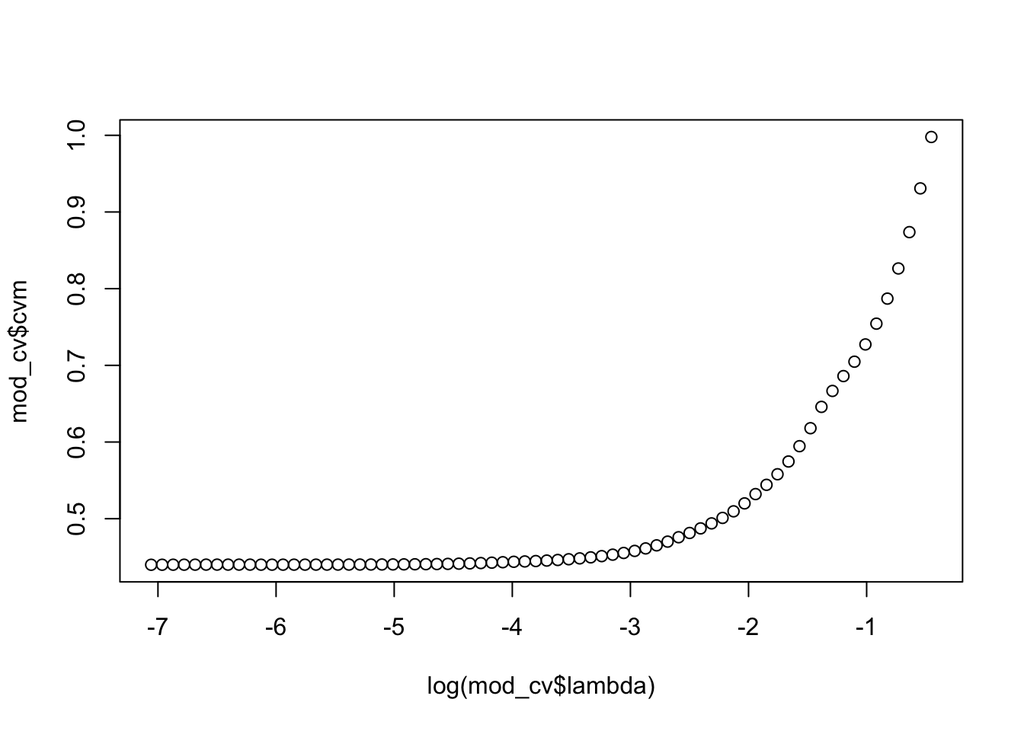

```r
mod_cv <- cv.glmnet(x=as.matrix(df[, -c(1, length(df))]),
                    y=df[, length(df)],
                    family='gaussian',
                    alpha=1)

# cvm : The mean cross-validated error - a vector of length length(lambda)
# lambda.min : the λ at which the minimal MSE is achieved.
# lambda.1se : the largest λ at which the MSE is within one standard error of the minimal MSE.

plot(log(mod_cv$lambda), mod_cv$cvm)
```

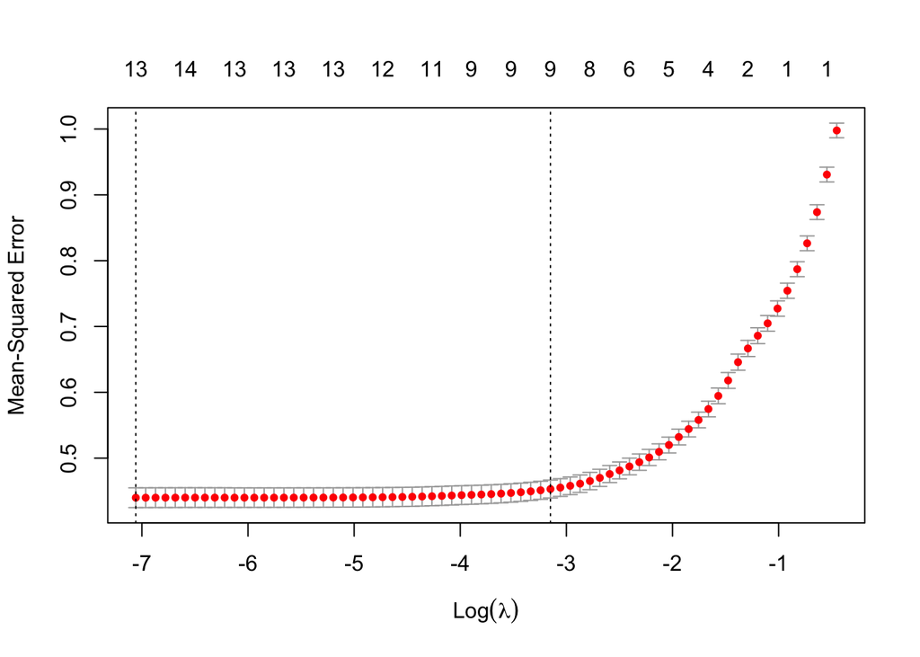

```r
plot(mod_cv)
```

```r
coef(mod_cv, c(mod_cv$lambda.min,
               mod_cv$lambda.1se))
```

```
## 15 x 2 sparse Matrix of class "dgCMatrix"
##                                                     s1            s2
## (Intercept)                              -0.0002910551  0.0001022544
## All.Students                             -0.2992232852 -0.2425761592
## Perc.Female                               0.0341460964  0.0012590799
## Perc.Economically.disadvantaged          -0.4511464042 -0.4230349342
## Perc.Black.or.African.American           -0.0610643062 -0.0453936132
## Perc.American.Indian.or.Alaska.Native    -0.0690370099 -0.0357695718
## Perc.Asian                                0.2324854996  0.1779540363
## Perc.Hispanic.or.Latino                   0.1150008545  .
## Perc.White                                .             .
## Perc.Not.a.high.school.graduate          -0.1723078745 -0.1138405868
## Perc.Reported.disabilities               -0.1182077099 -0.0942367074
## Perc.Two.or.more.races                    0.0335198803  .
## Perc.EL..English.learner.                -0.0153777758  .
## Perc.Filipino                             0.0145784889  .
## Perc.Native.Hawaiian.or.Pacific.Islander -0.0734353512 -0.0349326924
```

```r
print(paste(mod_cv$lambda.min,
            log(mod_cv$lambda.min)))
```

```
## [1] "0.000860882409444872 -7.05755263725987"
```

```r
print(paste(mod_cv$lambda.1se,
            log(mod_cv$lambda.1se)))
```

```
## [1] "0.0428463203792613 -3.15013550975483"
```

## K-means Clustering

```r
# scale. = FALSE/TRUE will return different proportion of variance explained
# but the contributions of each variable look alike
res.pca <- prcomp(caaspp22_ela, center = FALSE, scale. = FALSE)
summary(res.pca)
```

```
## Importance of components:
##                           PC1    PC2    PC3     PC4     PC5     PC6     PC7
## Standard deviation     2.0987 1.2455 1.2047 1.05986 1.00672 0.97248 0.90785
## Proportion of Variance 0.3146 0.1108 0.1037 0.08024 0.07239 0.06755 0.05887
## Cumulative Proportion  0.3146 0.4254 0.5291 0.60933 0.68172 0.74927 0.80814
##                            PC8     PC9    PC10    PC11    PC12    PC13    PC14
## Standard deviation     0.86551 0.78353 0.73712 0.59078 0.49723 0.42773 0.02107
## Proportion of Variance 0.05351 0.04385 0.03881 0.02493 0.01766 0.01307 0.00003
## Cumulative Proportion  0.86165 0.90550 0.94431 0.96924 0.98690 0.99997 1.00000
```

```
## [1] "proportions of variance:"
##  [1] 3.146178e-01 1.108024e-01 1.036720e-01 8.023527e-02 7.239176e-02
##  [6] 6.755143e-02 5.887055e-02 5.350756e-02 4.385117e-02 3.881092e-02
## [11] 2.493004e-02 1.765958e-02 1.306786e-02 3.171163e-05
```

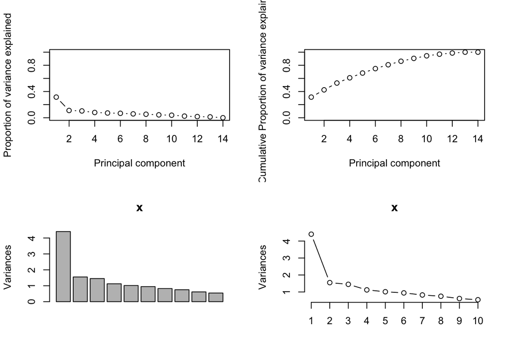

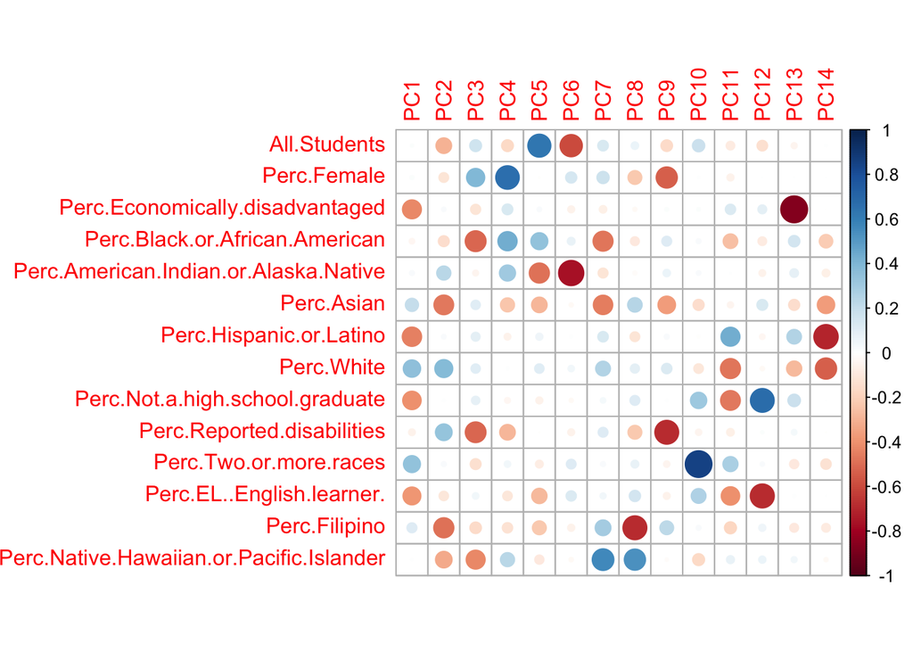

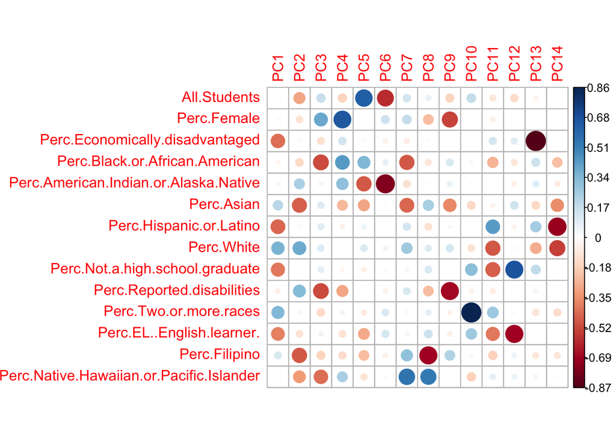

```r
pcaCharts <- function(x) {
    x.var <- x$sdev ^ 2
    x.pvar <- x.var/sum(x.var)
    print("proportions of variance:")
    print(x.pvar)

    par(mfrow=c(2,2))
    plot(x.pvar,xlab="Principal component", ylab="Proportion of variance explained", ylim=c(0,1), type='b')
    plot(cumsum(x.pvar),xlab="Principal component", ylab="Cumulative Proportion of variance explained", ylim=c(0,1), type='b')
    screeplot(x)
    screeplot(x,type="l")
    par(mfrow=c(1,1))
    corrplot(res.pca$rotation, is.corr=TRUE)
    corrplot(res.pca$rotation, is.corr=FALSE)
}

pcaCharts(res.pca)
```

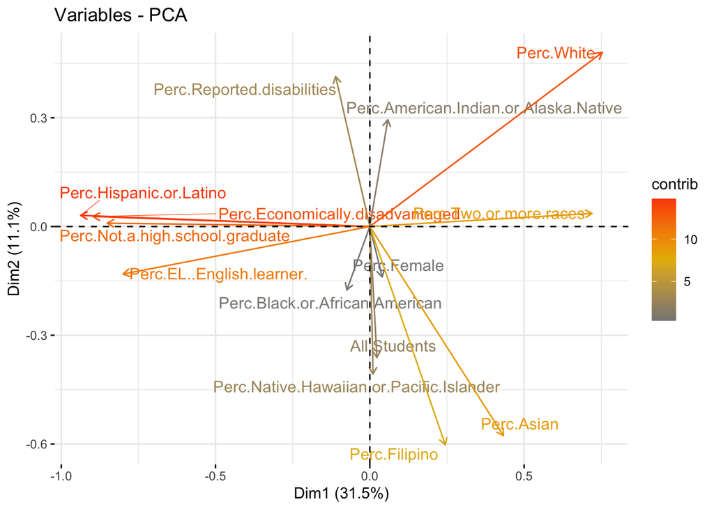

```r
fviz_pca_var(res.pca,
             col.var = "contrib", # Color by contributions to the PC
             gradient.cols = c("#868686FF", "#E7B800", "#FC4E07"),
             repel = TRUE,    # Avoid text overlapping
             )
```

```r
caaspp22_ela_pca = as.data.frame(-res.pca$x[,1:2])
```

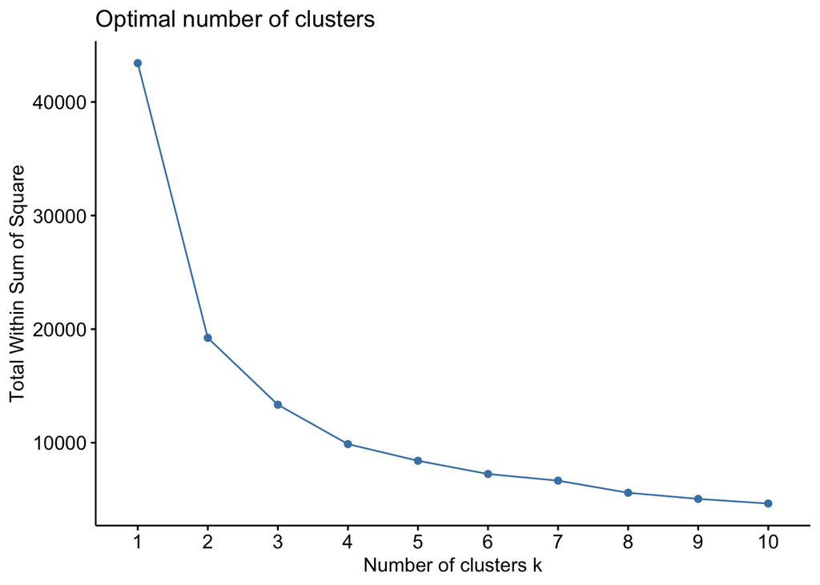

```r
fviz_nbclust(caaspp22_ela_pca,
             kmeans,
             method='wss' # the elbow shows up when k = 4
             #method='silhouette' # similarly suggest k = 3
             )
```

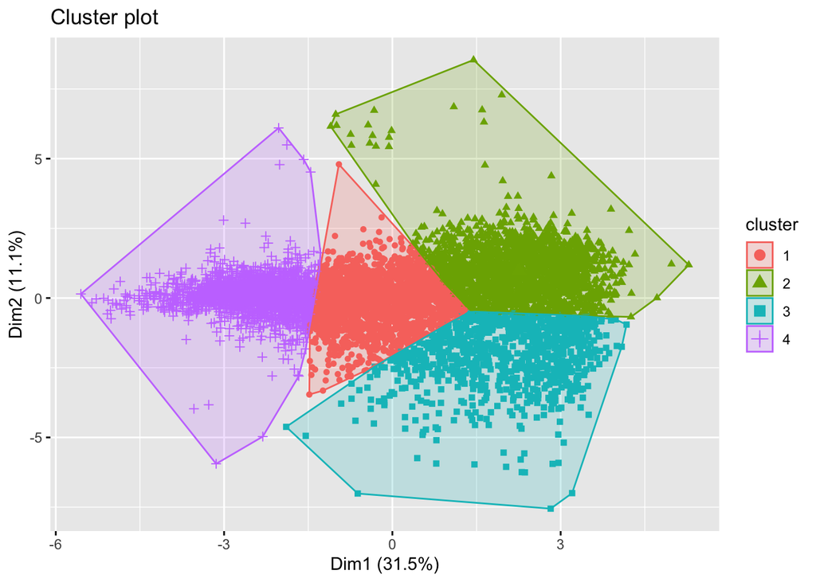

```r
res.km3 <- kmeans(caaspp22_ela_pca, 3)
res.km4 <- kmeans(caaspp22_ela_pca, 4)
#concern: not exactly same size
#print(res.km4)
fviz_cluster(res.km4, data=caaspp22_ela,
             geom="point")
```

```r
#It’s possible to compute the mean of each variables by clusters using the original data:
#aggregate(USArrests, by=list(cluster=km.res$cluster), mean)
```

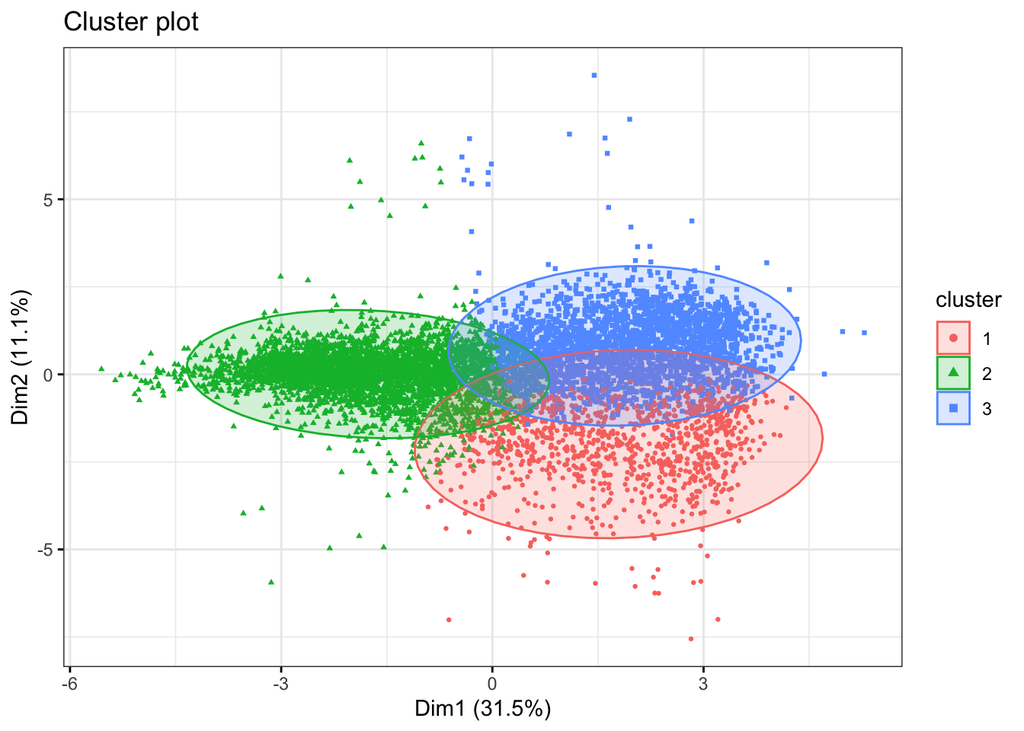

```r
res.km3.eclust <- eclust(caaspp22_ela, "kmeans", k = 3,
                 nstart = 25, graph = FALSE)
res.km4.eclust <- eclust(caaspp22_ela, "kmeans", k = 4,
                 nstart = 25, graph = FALSE)

fviz_cluster(res.km3.eclust,
            geom = "point",
            ellipse.type = "norm",
            ellipse.level = 0.95,
            ellipse.alpha = 0.2,
            pointsize = 0.8,
            ggtheme=theme_bw())
```

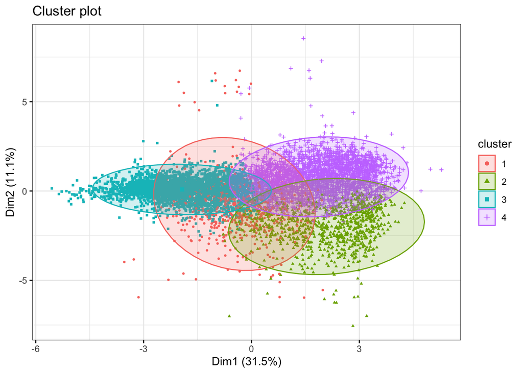

```r
fviz_cluster(res.km4.eclust,
            geom = "point",
            ellipse.type = "norm",
            ellipse.level = 0.95,
            ellipse.alpha = 0.2,
            pointsize = 0.8,
            ggtheme=theme_bw())
```

```
##   cluster size ave.sil.width
## 1       1 1042          0.05
## 2       2 3734          0.30
## 3       3 2515          0.26
```

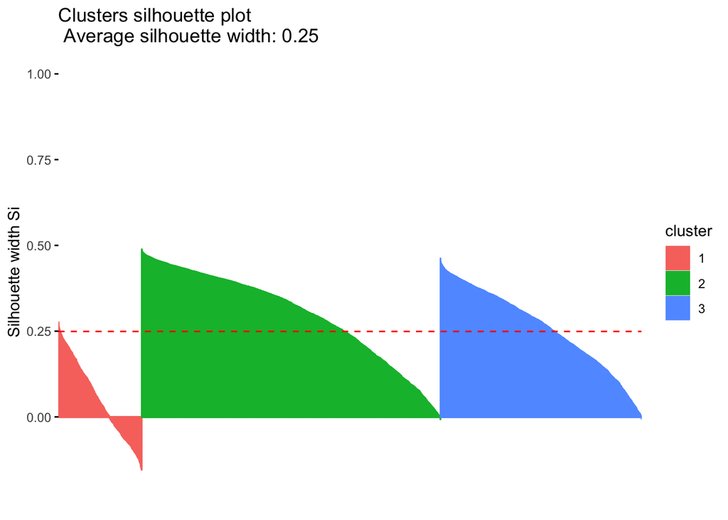

```r
fviz_silhouette(res.km3.eclust)
```

```
##   cluster size ave.sil.width
## 1       1  748         -0.04
## 2       2  861          0.11
## 3       3 3177          0.37
## 4       4 2505          0.24
```

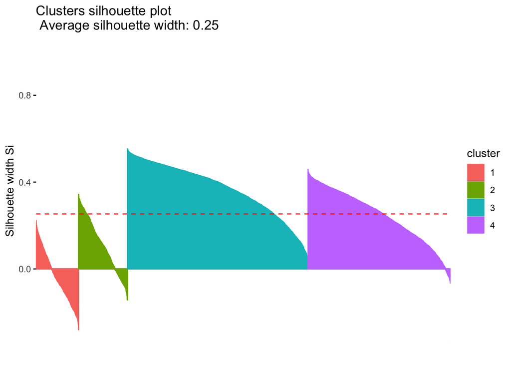

```r
fviz_silhouette(res.km4.eclust)
```

## Hierarchical Clustering

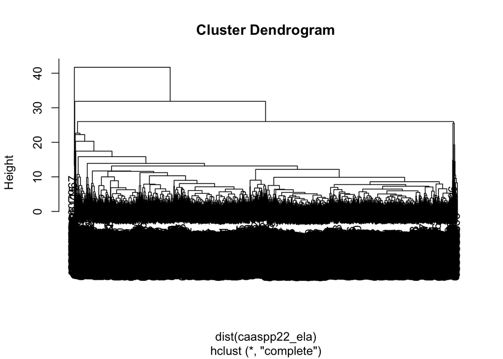

```r
#http://www.sthda.com/english/wiki/wiki.php?id_contents=8098
hclusters <- hclust(dist(caaspp22_ela))
plot(hclusters) # uneven distribution over 4 clusters
```

```r
# Enhanced hierarchical clustering
res.hc <- eclust(caaspp22_ela, "hclust", k = 4,
                method = "ward.D2", graph = FALSE)
head(res.hc$cluster, 15)
```

```
##  123968  124172  125567  131581  136101  137448 6001788 6002000  131763  111765
##       1       2       3       1       2       3       3       1       3       3
##  119222  122085  130609  131805  132142
##       2       2       2       2       2
```

```r
#fviz_dend(res.hc, rect = TRUE, show_labels = FALSE, cex = 0.5)
```

```r
#http://www.sthda.com/english/wiki/wiki.php?id_contents=8098
```